# Anova Factorial: 2 x 5

Said Jiménez y Florente López

10 de mayo de 2017

## Problema

Se trata de determinar el efecto de cinco grupos de aprendizaje y la edad en el número de palabras recordadas.

Es un diseño factorial de 2 x 5:

- El primer factor fue **edad** con dos niveles: Joven y Viejo.
- El segundo factor fue **método** con cinco niveles: Contar, Rimar, Adjetivo, Imagen, Intención.

Se utilizarán las siguientes librerías para realizar el análisis.

```r
library(readxl)
library(psych)
library(ggplot2)
library(car)
library(multcomp)
```

## Lectura de datos

```r
# Cargar datos
datos <- read_xlsx("memoriaEdad.xlsx", sheet = 2, range = cell_cols("A:C"))

# Convertir a factores edad y método
datos$edad <- factor(datos$edad, levels = c("joven", "viejo"), labels = c("Joven", "Viejo"))
datos$metodo <- factor(datos$metodo,
                       levels = c("contar", "rimar", "adjetivo", "imagen", "intencion"),
                       labels = c("Contar", "Rimar", "Adjetivo", "Imagen", "Intención"))

# Resumen
summary(datos)
```

```
##     edad          metodo      recuerdo
##  Joven:50   Contar   :20   Min.   : 3.00
##  Viejo:50   Rimar    :20   1st Qu.: 7.00
##             Adjetivo :20   Median :11.00
##             Imagen   :20   Mean   :11.61
##             Intención:20   3rd Qu.:15.25
##                            Max.   :23.00
```

## Estadísticos Descriptivos

Se obtienen los descriptivos, para la interacción de **edad * método**, los efectos principales de **edad** y **método**. Asimismo se extraen sólo las medias para su inspección.

```r
### Descriptivos
attach(datos)

# Descriptivos edad * método
(descI <- describeBy(recuerdo, edad:metodo, mat = TRUE, digits = 3))
```

```
##      item          group1 vars  n mean    sd median trimmed   mad min max
## X11     1    Joven:Contar    1 10  6.5 1.434    6.5   6.500 0.741   4   9
## X12     2     Joven:Rimar    1 10  7.6 1.955    7.0   7.750 1.483   4  10
## X13     3  Joven:Adjetivo    1 10 14.8 3.490   14.0  14.375 3.706  11  22
## X14     4    Joven:Imagen    1 10 17.6 2.591   17.0  17.500 2.965  14  22
## X15     5 Joven:Intención    1 10 19.3 2.669   20.0  19.500 2.965  15  22
## X16     6    Viejo:Contar    1 10  7.0 1.826    7.0   7.000 1.483   4  10
## X17     7     Viejo:Rimar    1 10  6.9 2.132    6.5   6.875 0.741   3  11
## X18     8  Viejo:Adjetivo    1 10 11.0 2.494   11.0  11.250 2.965   6  14
## X19     9    Viejo:Imagen    1 10 13.4 4.502   11.5  12.750 1.483   9  23
## X110   10 Viejo:Intención    1 10 12.0 3.742   11.0  12.000 2.965   5  19
##      range   skew kurtosis    se
## X11      5  0.000   -0.903 0.453
## X12      6 -0.135   -1.120 0.618
## X13     11  0.659   -0.770 1.104
## X14      8  0.225   -1.494 0.819
## X15      7 -0.321   -1.684 0.844
## X16      6  0.000   -1.218 0.577
## X17      8  0.178   -0.398 0.674
## X18      8 -0.657   -0.841 0.789
## X19     14  0.994   -0.532 1.424
## X110    14  0.046   -0.474 1.183
```

```r
# Descriptivos edad
(descE <- describeBy(recuerdo, edad, mat = TRUE, digits = 3))
```

```
##     item group1 vars  n  mean    sd median trimmed   mad min max range
## X11    1  Joven    1 50 13.16 5.787     14  13.075 8.154   4  22    18
## X12    2  Viejo    1 50 10.06 4.007     10   9.700 4.448   3  23    20
##      skew kurtosis    se
## X11 0.040   -1.423 0.818
## X12 0.856    0.964 0.567
```

```r
# Descriptivos método
(descM <- describeBy(recuerdo, metodo, mat = TRUE, digits = 3))
```

```
##     item    group1 vars  n  mean    sd median trimmed   mad min max range
## X11    1    Contar    1 20  6.75 1.618    7.0   6.750 1.483   4  10     6
## X12    2     Rimar    1 20  7.25 2.023    7.0   7.312 1.483   3  11     8
## X13    3  Adjetivo    1 20 12.90 3.538   13.0  12.750 2.965   6  22    16
## X14    4    Imagen    1 20 15.50 4.174   16.0  15.375 5.930   9  23    14
## X15    5 Intención    1 20 15.65 4.902   15.5  15.875 6.672   5  22    17
##       skew kurtosis    se
## X11  0.102   -0.777 0.362
## X12  0.002   -0.524 0.452
## X13  0.546    0.477 0.791
## X14  0.122   -1.296 0.933
## X15 -0.303   -0.998 1.096
```

```r
# Medias
(medias <- aggregate(recuerdo ~ edad + metodo, data = datos, FUN = mean))
```

```
##     edad    metodo recuerdo
## 1  Joven    Contar      6.5
## 2  Viejo    Contar      7.0
## 3  Joven     Rimar      7.6
## 4  Viejo     Rimar      6.9
## 5  Joven  Adjetivo     14.8
## 6  Viejo  Adjetivo     11.0
## 7  Joven    Imagen     17.6
## 8  Viejo    Imagen     13.4
## 9  Joven Intención     19.3
## 10 Viejo Intención     12.0
```

El siguiente chunk de código permite obtener la tabla de medias tal como la realizamos en excel.

```r
### Tabla de medias

# Convierte a matriz las medias
tabla_medias <-
  matrix(medias$recuerdo,
         nrow = 2,
         dimnames = list(c("joven", "viejo"),
                         c("contar", "rimar",
                           "adjetivo", "imagen",
                           "intencion")))

# Obtiene marginales de método
total.m <- apply(tabla_medias, 2, mean)

# Inserta marginales de método
tabla_medias <- rbind(tabla_medias, total.m)

# Obtiene marginales de edad
total.e <- apply(tabla_medias, 1, mean)

# Inserta marginales de edad: Lista!
(tabla_medias <- cbind(tabla_medias, total.e))
```

```
##         contar rimar adjetivo imagen intencion total.e
## joven     6.50  7.60     14.8   17.6     19.30   13.16
## viejo     7.00  6.90     11.0   13.4     12.00   10.06
## total.m   6.75  7.25     12.9   15.5     15.65   11.61
```

Como parte de la exploración, realizamos **boxplots** de las interacciones, así como de los efectos principales. Se alcanza a identificar una tendencia, que sugiere que a los jóvenes les va mejor en general, y que la distancia entre las edades se va marcando más de acuerdo al método de aprendizaje.

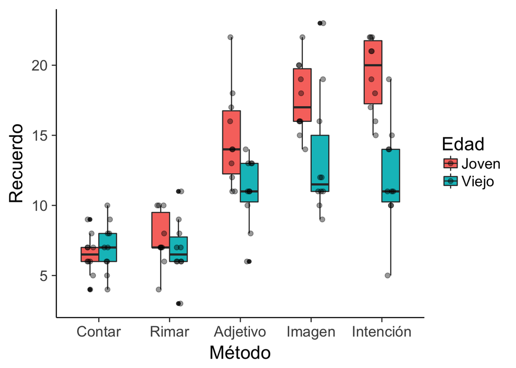

```r
### Gráficos

# Boxplot: Método x Recuerdo
ggplot(datos, aes(x = metodo, y = recuerdo, fill = edad)) +
  geom_boxplot(width = .5) +
  geom_point(position =
            position_jitterdodge(jitter.width = 0.2,
            dodge.width = 0.5), size = 2, alpha = 0.4) +
  labs(x = "Método",
       y = "Recuerdo",
       fill = "Edad") +
  theme_classic(base_size = 18, base_family = "")
```

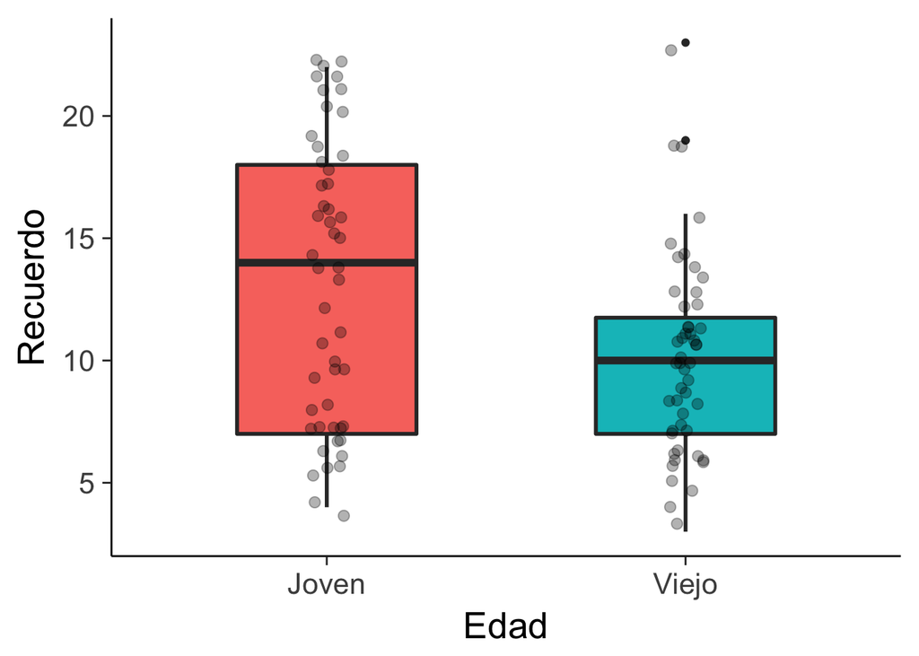

```r
# Boxplot por Edad
ggplot(datos, aes(x = edad, y = recuerdo, fill = edad)) +
  geom_boxplot(size = 1, width = 0.5) +
  geom_jitter(position = position_jitter(width = .05),
              alpha = 0.3,
              size = 2.5) +
  labs(x = "Edad",
       y = "Recuerdo",
       fill = NULL) +
  guides(fill = FALSE) +
  theme_classic(base_size = 20, base_family = "")
```

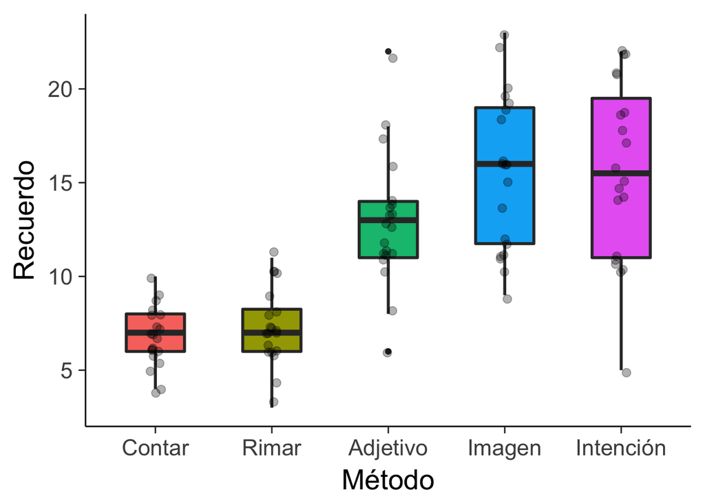

```r
# Boxplot por Método
ggplot(datos, aes(x = metodo, y = recuerdo, fill = metodo)) +
  geom_boxplot(size = 1, width = 0.5) +
  geom_jitter(position = position_jitter(width = .05),
              alpha = 0.3,
              size = 2.5) +
  labs(x = "Método",
       y = "Recuerdo",
       fill = NULL) +
  guides(fill = FALSE) +
  theme_classic(base_size = 20, base_family = "")
```

## Evaluación de los supuestos del ANOVA

Se evalúan los supuestos del análisis de varianza. Se puede observar que cumplimos con el requisito de homogeneidad de las varianzas para el término de interacción. No así para los efectos principales de edad y método.

De forma independiente se viola el supuesto para los dos grupos de edad, mientras que se mantiene para los cinco grupos de aprendizaje. Finalmente la prueba de **DurbinWatson** indica que hay independencia del error.

```r
### Supuestos de ANOVA

# Homogeneidad
leveneTest(recuerdo, edad:metodo)
```

```
## Levene's Test for Homogeneity of Variance (center = median)
##       Df F value Pr(>F)
## group  9  1.0312 0.4217
##       90
```

```r
leveneTest(recuerdo, edad)
```

```
## Levene's Test for Homogeneity of Variance (center = median)
##       Df F value    Pr(>F)
## group  1  14.507 0.0002436 ***
##       98
## ---
## Signif. codes:  0 '***' 0.001 '**' 0.01 '*' 0.05 '.' 0.1 ' ' 1
```

```r
leveneTest(recuerdo, metodo)
```

```
## Levene's Test for Homogeneity of Variance (center = median)
##       Df F value    Pr(>F)
## group  4  6.9145 6.271e-05 ***
##       95
## ---
## Signif. codes:  0 '***' 0.001 '**' 0.01 '*' 0.05 '.' 0.1 ' ' 1
```

```r
# Normalidad
tapply(recuerdo, edad:metodo, shapiro.test)
```

```
## $`Joven:Contar`
##
##  Shapiro-Wilk normality test
##
## data:  X[[i]]
## W = 0.96842, p-value = 0.8759
##
##
## $`Joven:Rimar`
##
##  Shapiro-Wilk normality test
##
## data:  X[[i]]
## W = 0.88705, p-value = 0.1571
##
##
## $`Joven:Adjetivo`
##
##  Shapiro-Wilk normality test
##
## data:  X[[i]]
## W = 0.92225, p-value = 0.3761
##
##
## $`Joven:Imagen`
##
##  Shapiro-Wilk normality test
##
## data:  X[[i]]
## W = 0.94138, p-value = 0.5685
##
##
## $`Joven:Intención`
##
##  Shapiro-Wilk normality test
##
## data:  X[[i]]
## W = 0.8799, p-value = 0.1302
##
##
```

[output cut: 23 more lines]

```
##
## $`Viejo:Imagen`
##
##  Shapiro-Wilk normality test
##
## data:  X[[i]]
## W = 0.81967, p-value = 0.02511
##
##
## $`Viejo:Intención`
##
##  Shapiro-Wilk normality test
##
## data:  X[[i]]
## W = 0.94339, p-value = 0.5913
```

```r
tapply(recuerdo, edad, shapiro.test)
```

```
## $Joven
##
##  Shapiro-Wilk normality test
##
## data:  X[[i]]
## W = 0.92423, p-value = 0.003364
##
##
## $Viejo
##
##  Shapiro-Wilk normality test
##
## data:  X[[i]]
## W = 0.94172, p-value = 0.01577
```

```r
tapply(recuerdo, metodo, shapiro.test)
```

```
## $Contar
##
##  Shapiro-Wilk normality test
##
## data:  X[[i]]
## W = 0.96143, p-value = 0.5728
##
##
## $Rimar
##
##  Shapiro-Wilk normality test
##
## data:  X[[i]]
## W = 0.94007, p-value = 0.2405
##
##
## $Adjetivo
##
##  Shapiro-Wilk normality test
##
## data:  X[[i]]
## W = 0.9485, p-value = 0.345
##
##
## $Imagen
##
##  Shapiro-Wilk normality test
##
## data:  X[[i]]
## W = 0.95096, p-value = 0.3819
##
##
## $Intención
##
##  Shapiro-Wilk normality test
##
## data:  X[[i]]
## W = 0.93903, p-value = 0.2298
```

```r
# Independencia del error
durbinWatsonTest(lm(recuerdo ~ edad:metodo))
```

```
##  lag Autocorrelation D-W Statistic p-value
##    1      -0.1710231      2.337547   0.422
##  Alternative hypothesis: rho != 0
```

## Análisis de varianza de una sola vía

Realizamos el análisis de varianza de una vía, sólo para ejemplificar que los resultados difieren al anova factorial.

```r
### Modelo ANOVA una vía por grupos: Just for fun!
datos[, 'gru'] <- with(datos, interaction(edad,  metodo))

modeloR <- lm(recuerdo ~ gru, datos)
summary(modeloR)
```

```
##
## Call:
## lm(formula = recuerdo ~ gru, data = datos)
##
## Residuals:
##    Min     1Q Median     3Q    Max
##   -7.0   -1.6   -0.5    2.0    9.6
##
## Coefficients:
##                    Estimate Std. Error t value Pr(>|t|)
## (Intercept)          6.5000     0.8959   7.256 1.35e-10 ***
## gruViejo.Contar      0.5000     1.2669   0.395 0.694031
## gruJoven.Rimar       1.1000     1.2669   0.868 0.387572
## gruViejo.Rimar       0.4000     1.2669   0.316 0.752943
## gruJoven.Adjetivo    8.3000     1.2669   6.551 3.46e-09 ***
## gruViejo.Adjetivo    4.5000     1.2669   3.552 0.000611 ***
## gruJoven.Imagen     11.1000     1.2669   8.761 1.08e-13 ***
## gruViejo.Imagen      6.9000     1.2669   5.446 4.43e-07 ***
## gruJoven.Intención  12.8000     1.2669  10.103  < 2e-16 ***
## gruViejo.Intención   5.5000     1.2669   4.341 3.70e-05 ***
## ---
## Signif. codes:  0 '***' 0.001 '**' 0.01 '*' 0.05 '.' 0.1 ' ' 1
##
## Residual standard error: 2.833 on 90 degrees of freedom
## Multiple R-squared:  0.7293, Adjusted R-squared:  0.7022
## F-statistic: 26.93 on 9 and 90 DF,  p-value: < 2.2e-16
```

```r
modeloA <- aov(recuerdo ~ gru, datos)
summary(modeloA)
```

```
##             Df Sum Sq Mean Sq F value Pr(>F)
## gru          9 1945.5  216.17   26.93 <2e-16 ***
## Residuals   90  722.3    8.03
## ---
## Signif. codes:  0 '***' 0.001 '**' 0.01 '*' 0.05 '.' 0.1 ' ' 1
```

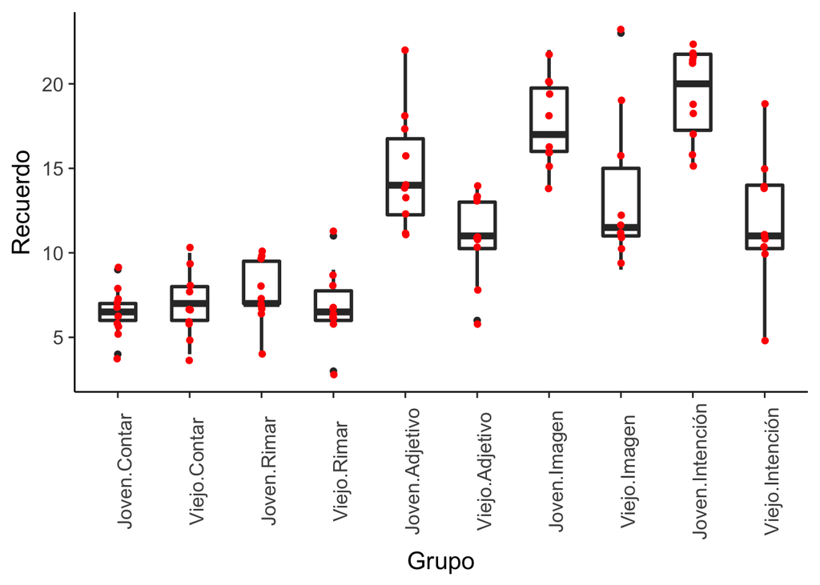

```r
ggplot(datos, aes(y = recuerdo, x = gru)) +
  geom_boxplot(size = 1, width = .5) +
  geom_jitter(position = position_jitter(width = .01),
              alpha = 1, color = "red", size = 1.5) +
  theme_classic(base_size = 15, base_family = "") +
  labs(x = "Grupo", y = "Recuerdo") +
  theme(axis.text.x = element_text(angle = 90, size = 12))
```

## Anova Factorial

Procedemos con la realización del modelo, incluye dos factores independientes y el término `edad:metodo` representa la interacción. La tabla de análisis de varianza especifica la suma de cuadrados tipo III. Como el término de interacción resulta significativo se debe proceder con la evaluación.

```r
### Anova Factorial

## Modelo general

# Especificamos contrastes
contrasts(datos$edad) <- c(-1,1)
contrasts(datos$metodo) <- cbind(c(-4, 1, 1, 1, 1),
                                 c(0, -3, 1, 1, 1),
                                 c(0, 0, -2, 1, 1),
                                 c(0, 0, 0, -1, 1))

# Especificamos el modelo con término de interacción
EM_model <- lm(recuerdo  ~  edad  +  metodo  +  edad:metodo,  data = datos)

# Suma de cuadrados tipo III
Anova(EM_model, type = "III")
```

```
## Anova Table (Type III tests)
##
## Response: recuerdo
##              Sum Sq Df   F value    Pr(>F)
## (Intercept) 13479.2  1 1679.5361 < 2.2e-16 ***
## edad          240.3  1   29.9356 3.981e-07 ***
## metodo       1514.9  4   47.1911 < 2.2e-16 ***
## edad:metodo   190.3  4    5.9279 0.0002793 ***
## Residuals     722.3 90
## ---
## Signif. codes:  0 '***' 0.001 '**' 0.01 '*' 0.05 '.' 0.1 ' ' 1
```

```r
# Inspeccionamos el output
summary.lm(EM_model, type = "III")
```

```
##
## Call:
## lm(formula = recuerdo ~ edad + metodo + edad:metodo, data = datos)
##
## Residuals:
##    Min     1Q Median     3Q    Max
##   -7.0   -1.6   -0.5    2.0    9.6
##
## Coefficients:
##               Estimate Std. Error t value Pr(>|t|)
## (Intercept)    11.6100     0.2833  40.982  < 2e-16 ***
## edad1          -1.5500     0.2833  -5.471 3.98e-07 ***
## metodo1         1.2150     0.1416   8.578 2.60e-13 ***
## metodo2         1.8583     0.1829  10.162  < 2e-16 ***
## metodo3         0.8917     0.2586   3.448 0.000861 ***
## metodo4         0.0750     0.4479   0.167 0.867401
## edad1:metodo1  -0.4500     0.1416  -3.177 0.002040 **
## edad1:metodo2  -0.5500     0.1829  -3.008 0.003413 **
## edad1:metodo3  -0.3250     0.2586  -1.257 0.212109
## edad1:metodo4  -0.7750     0.4479  -1.730 0.087024 .
## ---
## Signif. codes:  0 '***' 0.001 '**' 0.01 '*' 0.05 '.' 0.1 ' ' 1
##
## Residual standard error: 2.833 on 90 degrees of freedom
## Multiple R-squared:  0.7293, Adjusted R-squared:  0.7022
## F-statistic: 26.93 on 9 and 90 DF,  p-value: < 2.2e-16
```

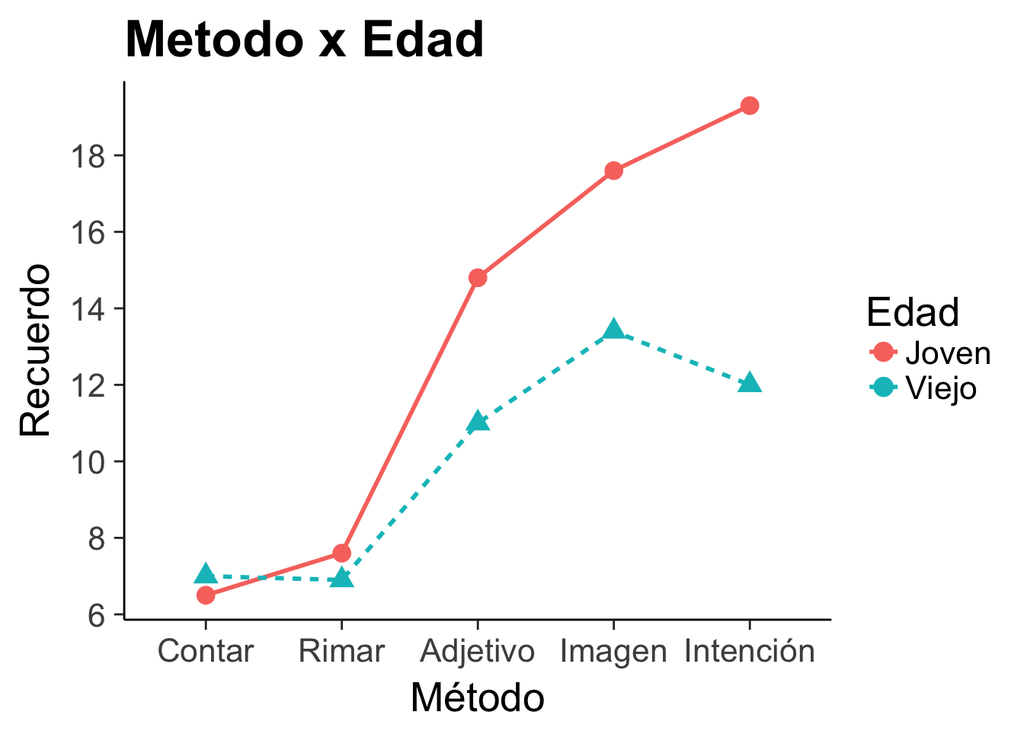

```r
# Gráfico de interacción
ggplot(datos, aes(x = metodo, y = recuerdo, lty = edad,
                  group = edad, shape = edad, col = edad)) +
  stat_summary(fun.y = mean, geom = "point", size = 4) +
  stat_summary(fun.y = mean, geom = "line", size = 1) +
  labs(x = "Método",
       y = "Recuerdo",
       col = "Edad",
       title = "Metodo x Edad" ) +
  guides(lty = FALSE, shape = FALSE) +
  theme_classic(base_size = 20, base_family = "") +
  theme(plot.title = element_text(size = 25, face = "bold", vjust = 2)) +
  scale_y_continuous(breaks = seq(4, 20, 2))
```

## Análisis de efectos simples

El análisis de los efectos simples se realiza cuando se obtiene que el término de interacción resulta significativo en el análisis general. Como fue el caso, procedemos con dicho análisis, el cuál pretende examinar la naturaleza de la interacción.

```r
### Análisis de efectos simples
datos$simple <- gl(10, 10, labels = c("E1M1", "E1M2", "E1M3", "E1M4", "E1M5",
                                      "E2M1", "E2M2", "E2M3", "E2M4", "E2M5"))

# Contrastes
contrasts(datos$simple) <- cbind(c(-4, 1, 1, 1, 1, -4, 1, 1, 1, 1), # método 1 contra todos los demás
                                 c(0, -3, 1, 1, 1, 0, -3, 1, 1, 1), # método 2 contra todos los demás
                                 c(0, 0, -2, 1, 1, 0, 0, -2, 1, 1), # método 3 contra todos los demás
                                 c(0, 0, 0, -1, 1, 0, 0, 0, -1, 1), # método 4 contra todos los demás
                                 c(-1, 0, 0, 0, 0, 1, 0, 0, 0, 0), # efecto de edad en método 1
                                 c(0, -1, 0, 0, 0, 0, 1, 0, 0, 0), # efecto de edad en método 2
                                 c(0, 0, -1, 0, 0, 0, 0, 1, 0, 0), # efecto de edad en método 3
                                 c(0, 0, 0, -1, 0, 0, 0, 0, 1, 0), # efecto de edad en método 4
                                 c(0, 0, 0, 0, -1, 0, 0, 0, 0, 1)) # efecto de edad en método 5

# Modelo de efectos simples
mod.efecto.simple <- lm(recuerdo ~ simple, data = datos)
summary.lm(mod.efecto.simple)
```

```
##
## Call:
## lm(formula = recuerdo ~ simple, data = datos)
##
## Residuals:
##    Min     1Q Median     3Q    Max
##   -7.0   -1.6   -0.5    2.0    9.6
##
## Coefficients:
##             Estimate Std. Error t value Pr(>|t|)
## (Intercept)  11.6100     0.2833  40.982  < 2e-16 ***
## simple1       1.2150     0.1416   8.578 2.60e-13 ***
## simple2       1.8583     0.1829  10.162  < 2e-16 ***
## simple3       0.8917     0.2586   3.448 0.000861 ***
## simple4       0.0750     0.4479   0.167 0.867401
## simple5       0.2500     0.6335   0.395 0.694031
## simple6      -0.3500     0.6335  -0.553 0.581964
## simple7      -1.9000     0.6335  -2.999 0.003498 **
## simple8      -2.1000     0.6335  -3.315 0.001322 **
## simple9      -3.6500     0.6335  -5.762 1.15e-07 ***
## ---
## Signif. codes:  0 '***' 0.001 '**' 0.01 '*' 0.05 '.' 0.1 ' ' 1
##
## Residual standard error: 2.833 on 90 degrees of freedom
## Multiple R-squared:  0.7293, Adjusted R-squared:  0.7022
## F-statistic: 26.93 on 9 and 90 DF,  p-value: < 2.2e-16
```

## Comparaciones Post-hoc

Las comparaciones post-hoc se realizan después de haber realizado el análisis de efectos simples y se realizan cuando no se especificaron las comparaciones a evaluar en el modelo a priori, o cuando se carece de hipótesis.

```r
### Comparaciones Post-hoc: Por si no hay hipótesis

# Corregidas por Bonferroni
pairwise.t.test(recuerdo, datos$simple, p.adjust = "bonferroni")
```

```
##
##  Pairwise comparisons using t tests with pooled SD
##
## data:  recuerdo and datos$simple
##
##      E1M1    E1M2    E1M3    E1M4    E1M5    E2M1    E2M2    E2M3
## E1M2 1.00000 -       -       -       -       -       -       -
## E1M3 1.6e-07 7.3e-06 -       -       -       -       -       -
## E1M4 4.9e-12 3.0e-10 1.00000 -       -       -       -       -
## E1M5 7.8e-15 5.0e-13 0.02750 1.00000 -       -       -       -
## E2M1 1.00000 1.00000 9.2e-07 3.2e-11 5.2e-14 -       -       -
## E2M2 1.00000 1.00000 6.4e-07 2.2e-11 3.6e-14 1.00000 -       -
## E2M3 0.02750 0.39001 0.15743 5.4e-05 1.6e-07 0.09754 0.07632 -
## E2M4 2.0e-05 0.00067 1.00000 0.05947 0.00050 0.00010 7.4e-05 1.00000
## E2M5 0.00167 0.03570 1.00000 0.00124 5.2e-06 0.00706 0.00533 1.00000
##      E2M4
## E1M2 -
## E1M3 -
## E1M4 -
## E1M5 -
## E2M1 -
## E2M2 -
## E2M3 -
## E2M4 -
## E2M5 1.00000
##
## P value adjustment method: bonferroni
```

```r
# Corregidas por Tukey
datos$todos <- with(datos, interaction(edad, metodo, sep = "x"))
model <- lm(recuerdo ~ todos, data = datos)
phTukey <- glht(model, linfct = mcp(todos = "Tukey"))

# Resultados
summary(phTukey)
```

```
##
##   Simultaneous Tests for General Linear Hypotheses
##
## Multiple Comparisons of Means: Tukey Contrasts
##
##
## Fit: lm(formula = recuerdo ~ todos, data = datos)
##
## Linear Hypotheses:
##                                        Estimate Std. Error t value
## ViejoxContar - JovenxContar == 0          0.500      1.267   0.395
## JovenxRimar - JovenxContar == 0           1.100      1.267   0.868
## ViejoxRimar - JovenxContar == 0           0.400      1.267   0.316
## JovenxAdjetivo - JovenxContar == 0        8.300      1.267   6.551
## ViejoxAdjetivo - JovenxContar == 0        4.500      1.267   3.552
## JovenxImagen - JovenxContar == 0         11.100      1.267   8.761
## ViejoxImagen - JovenxContar == 0          6.900      1.267   5.446
## JovenxIntención - JovenxContar == 0      12.800      1.267  10.103
## ViejoxIntención - JovenxContar == 0       5.500      1.267   4.341
## JovenxRimar - ViejoxContar == 0           0.600      1.267   0.474
## ViejoxRimar - ViejoxContar == 0          -0.100      1.267  -0.079
## JovenxAdjetivo - ViejoxContar == 0        7.800      1.267   6.157
## ViejoxAdjetivo - ViejoxContar == 0        4.000      1.267   3.157
## JovenxImagen - ViejoxContar == 0         10.600      1.267   8.367
## ViejoxImagen - ViejoxContar == 0          6.400      1.267   5.052
## JovenxIntención - ViejoxContar == 0      12.300      1.267   9.709
## ViejoxIntención - ViejoxContar == 0       5.000      1.267   3.947
## ViejoxRimar - JovenxRimar == 0           -0.700      1.267  -0.553
## JovenxAdjetivo - JovenxRimar == 0         7.200      1.267   5.683
## ViejoxAdjetivo - JovenxRimar == 0         3.400      1.267   2.684
## JovenxImagen - JovenxRimar == 0          10.000      1.267   7.893
## ViejoxImagen - JovenxRimar == 0           5.800      1.267   4.578
## JovenxIntención - JovenxRimar == 0       11.700      1.267   9.235
## ViejoxIntención - JovenxRimar == 0        4.400      1.267   3.473
## JovenxAdjetivo - ViejoxRimar == 0         7.900      1.267   6.236
## ViejoxAdjetivo - ViejoxRimar == 0         4.100      1.267   3.236
## JovenxImagen - ViejoxRimar == 0          10.700      1.267   8.446
## ViejoxImagen - ViejoxRimar == 0           6.500      1.267   5.131
## JovenxIntención - ViejoxRimar == 0       12.400      1.267   9.787
## ViejoxIntención - ViejoxRimar == 0        5.100      1.267   4.025
```

[output cut: 49 more lines]

```
## JovenxIntención - JovenxAdjetivo == 0    0.0202 *
## ViejoxIntención - JovenxAdjetivo == 0    0.4580
## JovenxImagen - ViejoxAdjetivo == 0        <0.01 ***
## ViejoxImagen - ViejoxAdjetivo == 0       0.6725
## JovenxIntención - ViejoxAdjetivo == 0     <0.01 ***
## ViejoxIntención - ViejoxAdjetivo == 0    0.9986
## ViejoxImagen - JovenxImagen == 0         0.0410 *
## JovenxIntención - JovenxImagen == 0      0.9410
## ViejoxIntención - JovenxImagen == 0       <0.01 **
## JovenxIntención - ViejoxImagen == 0       <0.01 ***
## ViejoxIntención - ViejoxImagen == 0      0.9830
## ViejoxIntención - JovenxIntención == 0    <0.01 ***
## ---
## Signif. codes:  0 '***' 0.001 '**' 0.01 '*' 0.05 '.' 0.1 ' ' 1
## (Adjusted p values reported -- single-step method)
```

```r
confint(phTukey)
```

```
##
##   Simultaneous Confidence Intervals
##
## Multiple Comparisons of Means: Tukey Contrasts
##
##
## Fit: lm(formula = recuerdo ~ todos, data = datos)
##
## Quantile = 3.2438
## 95% family-wise confidence level
##
##
## Linear Hypotheses:
##                                        Estimate   lwr        upr
## ViejoxContar - JovenxContar == 0         0.500000  -3.609706   4.609706
## JovenxRimar - JovenxContar == 0          1.100000  -3.009706   5.209706
## ViejoxRimar - JovenxContar == 0          0.400000  -3.709706   4.509706
## JovenxAdjetivo - JovenxContar == 0       8.300000   4.190294  12.409706
## ViejoxAdjetivo - JovenxContar == 0       4.500000   0.390294   8.609706
## JovenxImagen - JovenxContar == 0        11.100000   6.990294  15.209706
## ViejoxImagen - JovenxContar == 0         6.900000   2.790294  11.009706
## JovenxIntención - JovenxContar == 0     12.800000   8.690294  16.909706
## ViejoxIntención - JovenxContar == 0      5.500000   1.390294   9.609706
## JovenxRimar - ViejoxContar == 0          0.600000  -3.509706   4.709706
## ViejoxRimar - ViejoxContar == 0         -0.100000  -4.209706   4.009706
## JovenxAdjetivo - ViejoxContar == 0       7.800000   3.690294  11.909706
## ViejoxAdjetivo - ViejoxContar == 0       4.000000  -0.109706   8.109706
## JovenxImagen - ViejoxContar == 0        10.600000   6.490294  14.709706
## ViejoxImagen - ViejoxContar == 0         6.400000   2.290294  10.509706
## JovenxIntención - ViejoxContar == 0     12.300000   8.190294  16.409706
## ViejoxIntención - ViejoxContar == 0      5.000000   0.890294   9.109706
## ViejoxRimar - JovenxRimar == 0          -0.700000  -4.809706   3.409706
## JovenxAdjetivo - JovenxRimar == 0        7.200000   3.090294  11.309706
## ViejoxAdjetivo - JovenxRimar == 0        3.400000  -0.709706   7.509706
## JovenxImagen - JovenxRimar == 0         10.000000   5.890294  14.109706
## ViejoxImagen - JovenxRimar == 0          5.800000   1.690294   9.909706
## JovenxIntención - JovenxRimar == 0      11.700000   7.590294  15.809706
## ViejoxIntención - JovenxRimar == 0       4.400000   0.290294   8.509706
## JovenxAdjetivo - ViejoxRimar == 0        7.900000   3.790294  12.009706
## ViejoxAdjetivo - ViejoxRimar == 0        4.100000  -0.009706   8.209706
## JovenxImagen - ViejoxRimar == 0         10.700000   6.590294  14.809706
## ViejoxImagen - ViejoxRimar == 0          6.500000   2.390294  10.609706
## JovenxIntención - ViejoxRimar == 0      12.400000   8.290294  16.509706
## ViejoxIntención - ViejoxRimar == 0       5.100000   0.990294   9.209706
## ViejoxAdjetivo - JovenxAdjetivo == 0    -3.800000  -7.909706   0.309706
## JovenxImagen - JovenxAdjetivo == 0       2.800000  -1.309706   6.909706
## ViejoxImagen - JovenxAdjetivo == 0      -1.400000  -5.509706   2.709706
## JovenxIntención - JovenxAdjetivo == 0    4.500000   0.390294   8.609706
## ViejoxIntención - JovenxAdjetivo == 0   -2.800000  -6.909706   1.309706
## JovenxImagen - ViejoxAdjetivo == 0       6.600000   2.490294  10.709706
## ViejoxImagen - ViejoxAdjetivo == 0       2.400000  -1.709706   6.509706
## JovenxIntención - ViejoxAdjetivo == 0    8.300000   4.190294  12.409706
## ViejoxIntención - ViejoxAdjetivo == 0    1.000000  -3.109706   5.109706
## ViejoxImagen - JovenxImagen == 0        -4.200000  -8.309706  -0.090294
## JovenxIntención - JovenxImagen == 0      1.700000  -2.409706   5.809706
## ViejoxIntención - JovenxImagen == 0     -5.600000  -9.709706  -1.490294
## JovenxIntención - ViejoxImagen == 0      5.900000   1.790294  10.009706
## ViejoxIntención - ViejoxImagen == 0     -1.400000  -5.509706   2.709706
## ViejoxIntención - JovenxIntención == 0  -7.300000 -11.409706  -3.190294
```